# Load and visualize data from a variety of sources

### Plot the data

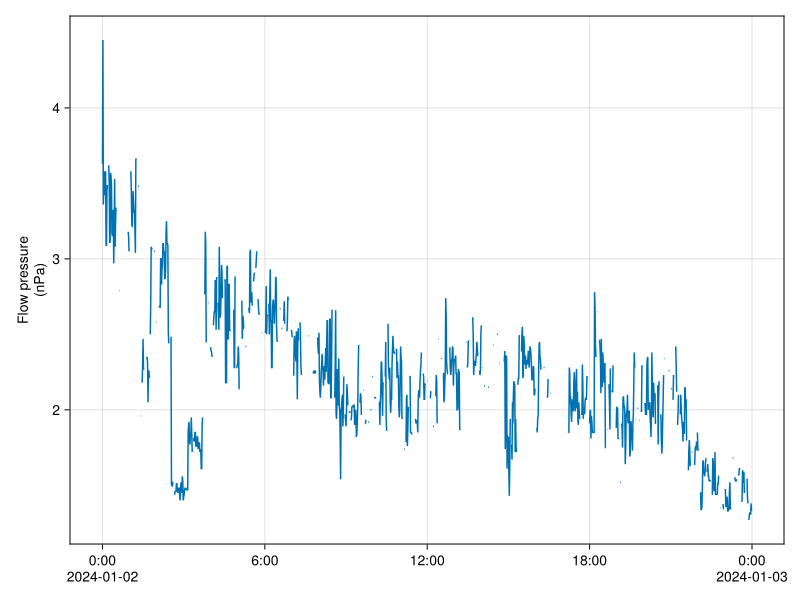

```julia
tplot(data2)
```

## Get data using Heliophysics Application Programmer’s Interface (HAPI)

HAPIClient.jl provides functions to load data from HAPI-compliant servers.

It could be installed at REPL via `using Pkg; Pkg.add("HAPIClient")`.

```julia
import HAPIClient

vars = HAPIClient.get_data("CDAWeb/AC_H0_MFI/Magnitude,BGSEc", t0, t1)
```

```
HAPIVariables: CDAWeb/AC_H0_MFI (https://cdaweb.gsfc.nasa.gov/hapi/data?time.min=2024-01-02T00%3A00%3A00.000Z&parameters=Magnitude%2CBGSEc&format=csv&id=AC_H0_MFI&time.max=2024-01-03T00%3A00%3A00.000Z)
  Magnitude [Time Range: 2024-01-02T00:00:12 to 2024-01-02T23:59:56, Units: nT, Size: (5400,)]
  BGSEc [Time Range: 2024-01-02T00:00:12 to 2024-01-02T23:59:56, Units: nT, Size: (5400, 3)]
Metadata - JSON.Object{String, Any} with 7 entries:
  "HAPI"        => "2.0"
  "resourceURL" => "https://cdaweb.gsfc.nasa.gov/misc/NotesA.html#AC_H0_MFI"
  "contact"     => "N. Ness @ Bartol Research Institute"
  "parameters"  => Any[Object{String, Any}("name"=>"Time", "length"=>24, "units…
  "startDate"   => "1997-09-02T00:00:12Z"
  "stopDate"    => "2025-11-07T23:59:44Z"
  "status"      => Object{String, Any}("code"=>1200, "message"=>"OK")
```

### Plot the data

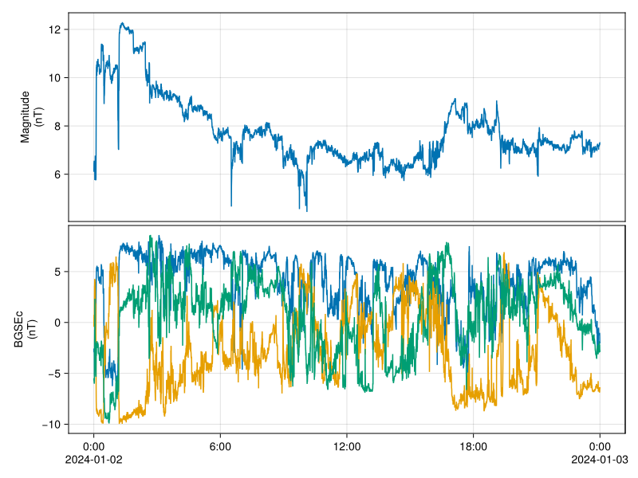

```julia
tplot(vars)
```

## Get data with `PySPEDAS`

PySPEDAS.jl provides a Julia interface to the [PySPEDAS](https://github.com/spedas/pyspedas) Python package, offering a similar API for Julia users to utilize the existing Python routines.

It could be installed at REPL via `using Pkg; Pkg.add("PySPEDAS")`.

```julia
using PySPEDAS.Projects

# Same as more verbose `pyspedas.projects.themis.fgm(...)`
tvars = themis.fgm([t0, t1], time_clip=true, probe="d");
```

```
23-Nov-25 23:12:21: Downloading remote index: https://themis.ssl.berkeley.edu/data/themis/thd/l2/fgm/2024/
23-Nov-25 23:12:22: File is current: /Users/zijin/data/themis/thd/l2/fgm/2024/thd_l2_fgm_20240102_v01.cdf
```

### Plot the data

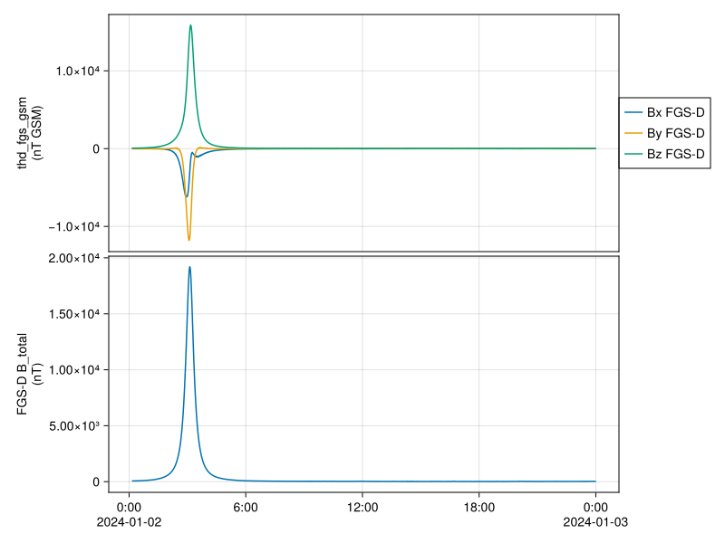

```julia
tplot((tvars.thd_fgs_gsm, tvars.thd_fgs_btotal))
```

## Composite plot

Combine all the data into a single plot with multiple panels.

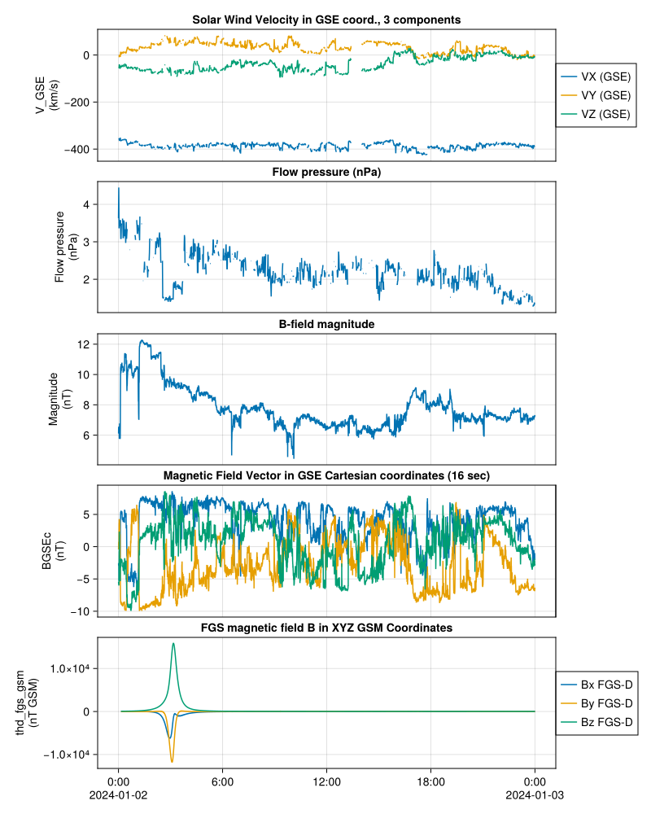

```julia
tplot((data1, data2, vars..., tvars.thd_fgs_gsm), add_title=true)
```

## Reproducibility

**NoteThis tutorial was built using these direct dependencies**

```julia
using Pkg
Pkg.status()
```

```
Status `~/src/juliaspacephysics.github.io/tutorials/data_loading/Project.toml`
  [950ff2a9] CDAWeb v0.1.4
  [075ae62b] CDFDatasets v0.1.8 `~/.julia/dev/CDFDatasets`
  [13f3f980] CairoMakie v0.15.7
  [0703355e] DimensionalData v0.29.25
  [0ce0b37c] HAPIClient v0.2.2
  [668d2cef] PySPEDAS v0.1.6
  [0b37b92c] SpaceDataModel v0.2.2 `~/.julia/dev/SpaceDataModel`
  [0c28ffd8] SpacePhysicsMakie v0.2.4 `~/.julia/dev/SpacePhysicsMakie`
  [09b745ad] Speasy v0.4.8
```

**NoteMachine and Julia version information**

```julia
using InteractiveUtils # hide
versioninfo()
```

```
Julia Version 1.12.2
Commit ca9b6662be4 (2025-11-20 16:25 UTC)
Build Info:
  Official https://julialang.org release
Platform Info:
  OS: macOS (arm64-apple-darwin24.0.0)
  CPU: 12 × Apple M2 Max
  WORD_SIZE: 64
  LLVM: libLLVM-18.1.7 (ORCJIT, apple-m2)
  GC: Built with stock GC
Threads: 1 default, 1 interactive, 1 GC (on 8 virtual cores)
Environment:
  JULIA_PROJECT = @.
  JULIA_LOAD_PATH = @:@stdlib
```

Back to top